# EP11: herramientas avanzadas para modelos de regresión

#### 1. Debe existir una relación lineal entre los predictores y la respuesta transformada.

```r
formula_texto <- paste("EN", paste(mejores_predictores_logit, collapse = " + "), sep = " ~ ")
formula_logit <- as.formula(formula_texto)
modelo_final_logit <- glm(formula_logit, data = datos, family = binomial(link = "logit"))

summary(modelo_final_logit)
```

```
##
## Call:
## glm(formula = formula_logit, family = binomial(link = "logit"),
##     data = datos)
##
## Coefficients:
##              Estimate Std. Error z value Pr(>|z|)
## (Intercept) -38.62695    9.35165  -4.130 3.62e-05 ***
## Waist.Girth   0.34530    0.13023   2.651  0.00802 **
## Bicep.Girth   0.33312    0.20693   1.610  0.10743
## Gender       -3.27144    1.85330  -1.765  0.07753 .
## Knee.Girth   -0.07526    0.25538  -0.295  0.76824
## Navel.Girth   0.09265    0.09070   1.021  0.30702
## Age          -0.04560    0.04417  -1.032  0.30188
## ---
## Signif. codes:  0 '***' 0.001 '**' 0.01 '*' 0.05 '.' 0.1 ' ' 1
##
## (Dispersion parameter for binomial family taken to be 1)
##
##     Null deviance: 138.629  on 99  degrees of freedom
## Residual deviance:  51.888  on 93  degrees of freedom
## AIC: 65.888
##
## Number of Fisher Scoring iterations: 7
```

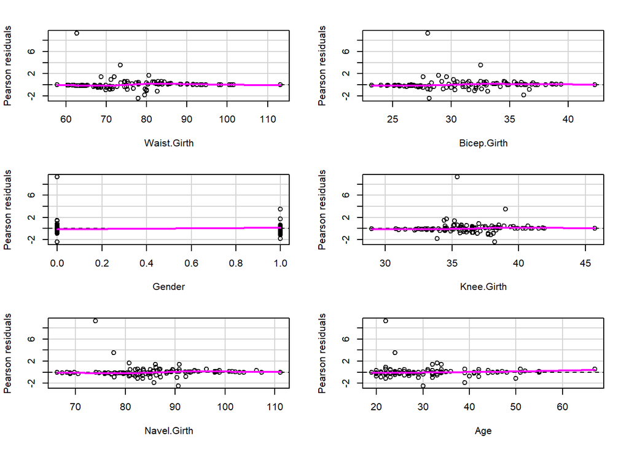

```
##             Test stat Pr(>|Test stat|)
## Waist.Girth    2.5862           0.1078
## Bicep.Girth    0.7869           0.3750
## Gender         0.0000           1.0000
## Knee.Girth     0.1299           0.7186
## Navel.Girth    1.4845           0.2231
## Age            0.4726           0.4918
```

```r
residualPlots(modelo_final_logit, fitted = FALSE)
```

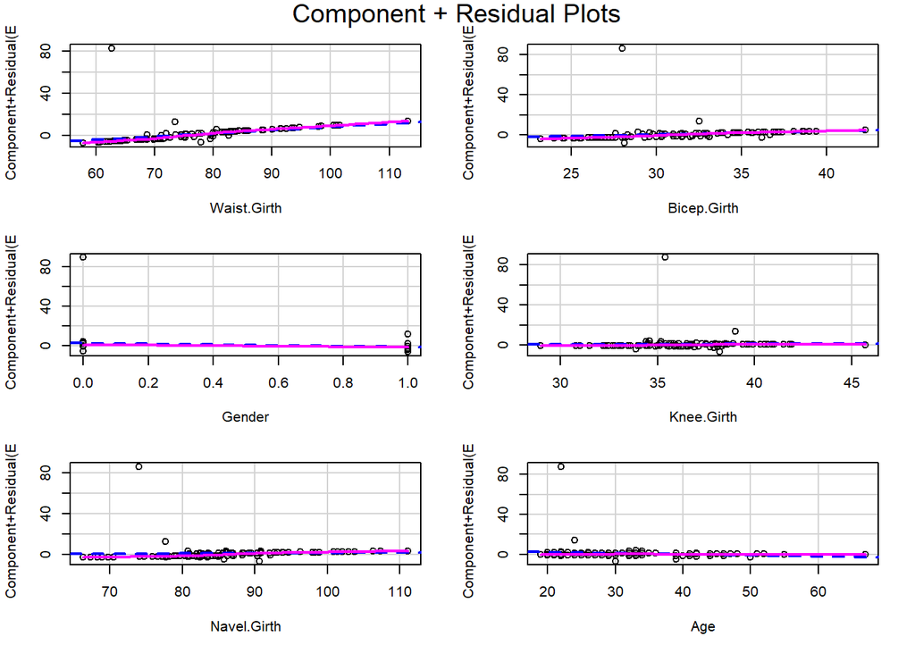

```r
crPlots(modelo_final_logit)
```

Dado los resultados de la prueba de curvatura, reportados por `residualPlots()`, confirman que se cumple el supuesto de linealidad entre los predictores y la respuesta transformada. Es importante decir que “Gender” genera un p de 1, además de que produce warnings de convergencia, por ahora continuaremos para analizar otros parámetros.

#### 2. Los residuos deben ser independientes entre sí.

```r
set.seed(20994)
durbinWatsonTest(modelo_final_logit)
```

```
##  lag Autocorrelation D-W Statistic p-value
##    1     -0.02379143      2.042907   0.848
##  Alternative hypothesis: rho != 0
```

La prueba de Durbin-Watson resultó no significativa, con un $p$ de $0.848$, por lo que se descarta que no se cumpla la condición de independencia de los residuos.

#### 3. Multicolinealidad entre los predictores.

```r
cat("Inflación de la varianza:\n")
```

```
## Inflación de la varianza:
```

```r
print(vif(modelo_final_logit))
```

```
## Waist.Girth Bicep.Girth      Gender  Knee.Girth Navel.Girth         Age
##    4.528267    2.952777    6.855882    1.513985    2.154058    1.605549
```

```r
cat("\n")
```

```r
cat("Valores de tolerancia:\n")
```

```
## Valores de tolerancia:
```

```r
print(1 / vif(modelo_final_logit))
```

```
## Waist.Girth Bicep.Girth      Gender  Knee.Girth Navel.Girth         Age
##   0.2208351   0.3386642   0.1458601   0.6605083   0.4642401   0.6228401
```

Los factores de inflación de varianza son relativamente bajos, entre 1 y 5, lo que indica una multicolinealidad moderada, excepto para “Gender” que da una inflación de la varianza mayor a 5 y una tolerancia menor a 0.2, por ello eliminaremos este predictor del modelo.

```r
# Ejecutar RFE para encontrar el mejor conjunto de predictores sin contar "Gender"
modelo_rfe_logit_v2 <- rfe(x = datos[, !names(datos) %in% c("Gender","Weight", "Height", "IMC", "EN")],
                        y = datos$EN,
                        # Probar subconjuntos de 2 a 6 predictores
                        sizes = 2:6,
                        rfeControl = rfe_control_logit,
                        metric = "ROC")

# Imprimir los resultados de RFE
modelo_logit_v2 <- modelo_rfe_logit_v2[["fit"]]
print(summary(modelo_logit_v2))
```

```
##
## Call:
## glm(formula = Class ~ ., family = "binomial", data = tmp)
##
## Coefficients:
##                      Estimate Std. Error z value Pr(>|z|)
## (Intercept)         -58.23452   15.26998  -3.814 0.000137 ***
## Waist.Girth           0.28657    0.11279   2.541 0.011059 *
## Bicep.Girth           0.15824    0.17222   0.919 0.358191
## Thigh.Girth           0.49995    0.18258   2.738 0.006177 **
## Ankles.diameter      -0.05462    0.57438  -0.095 0.924237
## Ankle.Minimum.Girth  -0.05576    0.40265  -0.138 0.889866
## Navel.Girth           0.06035    0.07613   0.793 0.427894
## ---
## Signif. codes:  0 '***' 0.001 '**' 0.01 '*' 0.05 '.' 0.1 ' ' 1
##
## (Dispersion parameter for binomial family taken to be 1)
##
##     Null deviance: 138.63  on 99  degrees of freedom
## Residual deviance:  42.84  on 93  degrees of freedom
## AIC: 56.84
##
## Number of Fisher Scoring iterations: 7
```

```r
# Imprimir los mejores predictores encontrados
mejores_predictores_logit_v2 <- predictors(modelo_rfe_logit_v2)
print(mejores_predictores_logit_v2)
```

```
## [1] "Waist.Girth"         "Bicep.Girth"         "Thigh.Girth"
## [4] "Ankles.diameter"     "Ankle.Minimum.Girth" "Navel.Girth"
```

Habiendo eliminado “Gender” del modelo, proseguiremos a revisar nuevamente las condiciones.

```r
formula_texto_v2 <- paste("EN", paste(mejores_predictores_logit_v2, collapse = " + "), sep = " ~ ")
formula_logit_v2 <- as.formula(formula_texto_v2)

modelo_final_logit_v2 <- glm(formula_logit_v2, data = datos, family = binomial(link = "logit"))
summary(modelo_final_logit_v2)
```

```
##
## Call:
## glm(formula = formula_logit_v2, family = binomial(link = "logit"),
##     data = datos)
##
## Coefficients:
##                      Estimate Std. Error z value Pr(>|z|)
## (Intercept)         -58.23452   15.26998  -3.814 0.000137 ***
## Waist.Girth           0.28657    0.11279   2.541 0.011059 *
## Bicep.Girth           0.15824    0.17222   0.919 0.358191
## Thigh.Girth           0.49995    0.18258   2.738 0.006177 **
## Ankles.diameter      -0.05462    0.57438  -0.095 0.924237
## Ankle.Minimum.Girth  -0.05576    0.40265  -0.138 0.889866
## Navel.Girth           0.06035    0.07613   0.793 0.427894
## ---
## Signif. codes:  0 '***' 0.001 '**' 0.01 '*' 0.05 '.' 0.1 ' ' 1
##
## (Dispersion parameter for binomial family taken to be 1)
##
##     Null deviance: 138.63  on 99  degrees of freedom
## Residual deviance:  42.84  on 93  degrees of freedom
## AIC: 56.84
##
## Number of Fisher Scoring iterations: 7
```

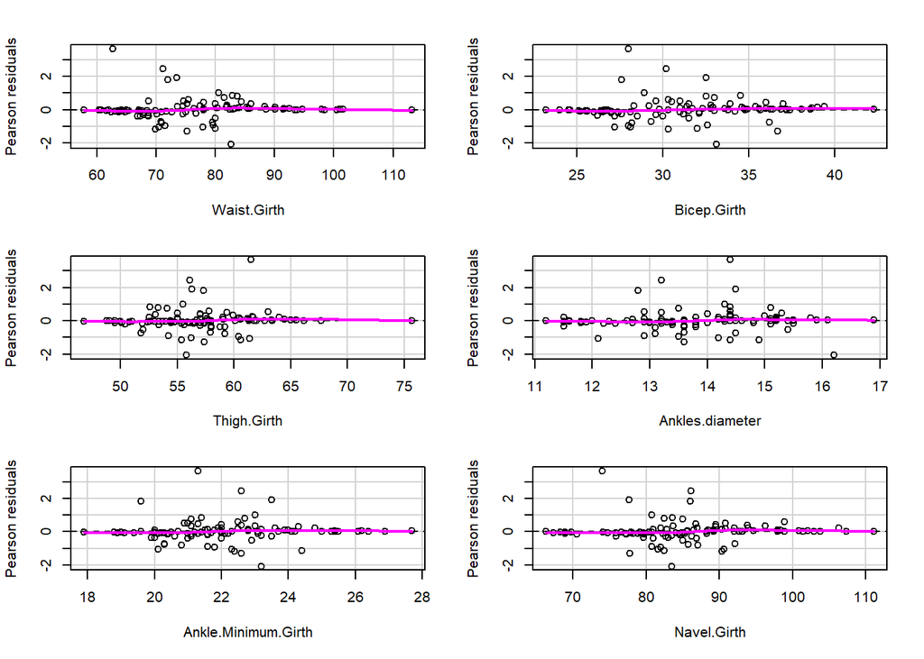

```
##                     Test stat Pr(>|Test stat|)
## Waist.Girth            3.0932          0.07862 .
## Bicep.Girth            0.6355          0.42534
## Thigh.Girth            0.0170          0.89615
## Ankles.diameter        2.5063          0.11339
## Ankle.Minimum.Girth    0.0509          0.82142
## Navel.Girth            1.7580          0.18488
## ---
## Signif. codes:  0 '***' 0.001 '**' 0.01 '*' 0.05 '.' 0.1 ' ' 1
```

```r
residualPlots(modelo_final_logit_v2, fitted = FALSE)
```

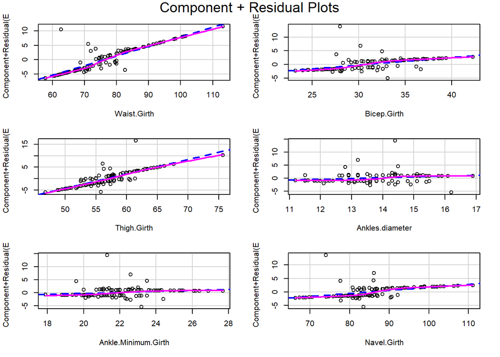

```r
crPlots(modelo_final_logit_v2)
```

Ahora se obtienen valores p no significativos para todos los predictores, por lo que se concluye que se cumple el supuesto de linealidad entre los predictores y la respuesta transformada. Igualmente, hay warnings de convergencia, por lo que seguiremos revisando las métricas a detalle para evaluar la posible eliminación de otro predictor.

#### 2. Los residuos deben ser independientes entre sí.

```r
set.seed(20994)
durbinWatsonTest(modelo_final_logit_v2)
```

```
##  lag Autocorrelation D-W Statistic p-value
##    1     -0.02056822      2.038658   0.854
##  Alternative hypothesis: rho != 0
```

La prueba de Durbin-Watson resultó no significativa, con un $p$ de $0.854$, por lo que se descarta que no se cumpla la condición de independencia de los residuos.

#### 3. Multicolinealidad entre los predictores.

```r
cat("Inflación de la varianza:\n")
```

```
## Inflación de la varianza:
```

```r
print(vif(modelo_final_logit_v2))
```

```
##         Waist.Girth         Bicep.Girth         Thigh.Girth     Ankles.diameter
##            2.854615            1.772099            2.036524            2.029282
## Ankle.Minimum.Girth         Navel.Girth
##            1.636845            1.204059
```

```r
cat("\n")
```

```r
cat("Valores de tolerancia:\n")
```

```
## Valores de tolerancia:
```

```r
print(1 / vif(modelo_final_logit_v2))
```

```
##         Waist.Girth         Bicep.Girth         Thigh.Girth     Ankles.diameter
##           0.3503099           0.5643026           0.4910328           0.4927851
## Ankle.Minimum.Girth         Navel.Girth
##           0.6109312           0.8305242
```

Con respecto a la multicolinealidad, se obtienen factores de inflación de varianza bajos, entre 1 y 5 (de hecho, menores a 3), de esto se puede concluir que existe una multicolinealidad moderada, pero ya que estos valores son relativamente bajos, no se concluye que sean suficientemente relevantes para causar preocupación, con respecto a la tolerancia, se encuentran valores mayores a 0.3, permitiendo concluir lo mismo que con los factores de inflación.

#### 4. Tamaño de muestra (observaciones suficientes para todas las posibles combinaciones de predictores, en especial para algún nivel de una variable categórica).

Ya que los predictores son numéricos, se requiere un mínimo de 90 observaciones, considerando 15 por cada uno, por lo tanto, se cumple, ya que hay 100 observaciones.

#### 5. Las estimaciones de los coeficientes del modelo no están dominadas por casos influyentes.

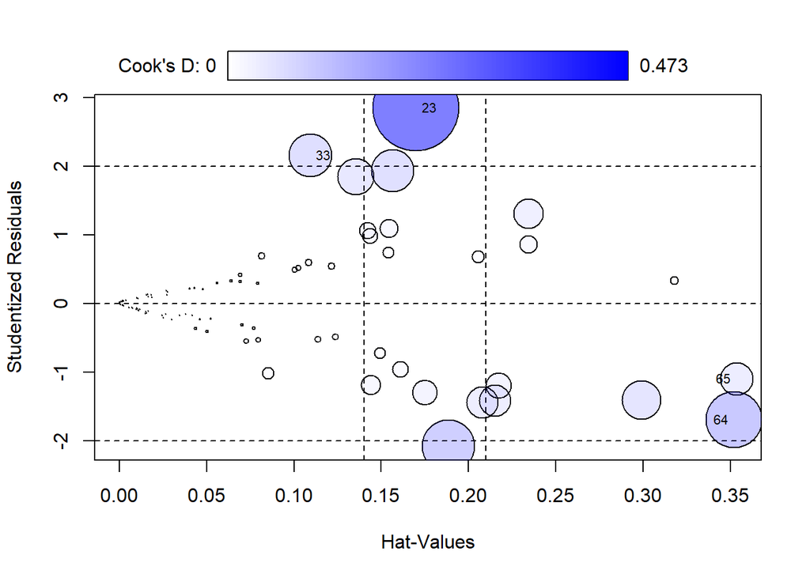

```
##      StudRes       Hat      CookD
## 64 -1.694672 0.3520741 0.20010696
## 33  2.149889 0.1093726 0.11786788
## 23  2.843075 0.1698666 0.47254675
## 65 -1.097169 0.3533905 0.06816985
```

```r
influencePlot(modelo_final_logit_v2, id = list(cex = 0.7))
```

El doble del apalancamiento promedio vendría a ser aproximadamente $2\cdot\frac{6+1}{100}=\frac{7}{50} = 0.14$. Con este valor se puede identificar que los 3 puntos, 64, 23 y 65, no cumplen con la condición de ser menores que el doble del apalancamiento promedio, lo que indica que son puntos influyentes. Sin embargo, al observar los valores correspondientes a la distancia de Cook, estos son sumamente bajos y menores que 1, por lo que no deberían influir en la línea de regresión asociada al RLog múltiple.

#### Ajuste

```r
modelo_nulo_logit <- glm(EN ~ 1, data = datos, family = binomial(link = "logit"))
anova_rlm <- anova(modelo_nulo_logit, modelo_final_logit_v2, test = "LRT")

cat("Bondad de ajuste del modelo RLogM:\n")
```

```
## Bondad de ajuste del modelo RLogM:
```

```r
print(anova_rlm)
```

```
## Analysis of Deviance Table
##
## Model 1: EN ~ 1
## Model 2: EN ~ Waist.Girth + Bicep.Girth + Thigh.Girth + Ankles.diameter +
##     Ankle.Minimum.Girth + Navel.Girth
##   Resid. Df Resid. Dev Df Deviance  Pr(>Chi)
## 1        99     138.63
## 2        93      42.84  6    95.79 < 2.2e-16 ***
## ---
## Signif. codes:  0 '***' 0.001 '**' 0.01 '*' 0.05 '.' 0.1 ' ' 1
```

En el RLogM se puede observar una reducción de la devianza de $95.79$, con respecto al modelo nulo, y un p-value significativo de $2.2*10 ^ {-16}$ indicando que el modelo posee una buena bondad de ajuste.

#### Poder predictivo

```r
set.seed(20994)
modelo_ent_logit <- train(EN ~ ., data = datos[, c(mejores_predictores_logit_v2, "EN")],
                    method = "glm",family = binomial(link = "logit"),
                    trControl = trainControl(method = "LOOCV",
                                            savePredictions = TRUE,
                                            classProbs = TRUE, summaryFunction = twoClassSummary),
                    metric = "ROC")


# Matriz de confusión general (LOOCV)
confusionMatrix(modelo_ent_logit$pred$pred, modelo_ent_logit$pred$obs)
```

```
## Confusion Matrix and Statistics
##
##              Reference
## Prediction    Sobrepeso NoSobrepeso
##   Sobrepeso          41           5
##   NoSobrepeso         9          45
##
##                Accuracy : 0.86
##                  95% CI : (0.7763, 0.9213)
##     No Information Rate : 0.5
##     P-Value [Acc > NIR] : 4.142e-14
##
##                   Kappa : 0.72
##
##  Mcnemar's Test P-Value : 0.4227
##
##             Sensitivity : 0.8200
##             Specificity : 0.9000
##          Pos Pred Value : 0.8913
##          Neg Pred Value : 0.8333
##              Prevalence : 0.5000
##          Detection Rate : 0.4100
##    Detection Prevalence : 0.4600
##       Balanced Accuracy : 0.8600
##
##        'Positive' Class : Sobrepeso
##
```

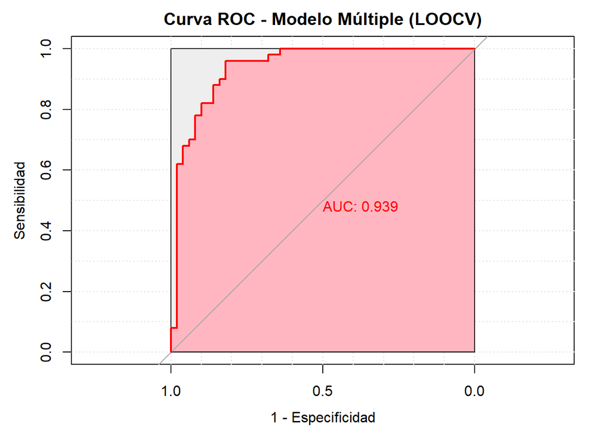

```r
# Probabilidades de la clase positiva
probs <- modelo_ent_logit$pred$Sobrepeso

# Clases observadas
obs <- modelo_ent_logit$pred$obs

# Calcular curva ROC
roc_obj <- roc(obs, probs, direction = "<", levels = c("NoSobrepeso", "Sobrepeso"))

# Graficar curva ROC
plot(roc_obj,
     main = "Curva ROC - Modelo Múltiple (LOOCV)",
     col = "red",
     print.auc = TRUE,
     auc.polygon = TRUE,
     grid = TRUE,
     auc.polygon.col = "lightpink",
     max.auc.polygon = TRUE,
     xlab = "1 - Especificidad",
     ylab = "Sensibilidad")
```

El modelo obtuvo una exactitud del 86%, lo que indica que clasifica correctamente la mayoría de los casos. La sensibilidad fue de 82% y la especificidad de 90%, lo que significa que identifica bien tanto a personas con sobrepeso como sin él. Además, el área bajo la curva ROC (AUC) fue de 0.939, lo que muestra un excelente rendimiento general del modelo para distinguir entre ambas clases.